# Understanding the influence of precipitation timing and variability on dryland GPP

Guy Lomax

2022-08-29

This analysis uses Generalised Additive Models (GAMs) to explore the relationship between different dimensions of precipitation variability and vegetation productivity across African rangelands. The notebook calculates mean values of different metrics of precipitation patterns and for gross primary productivity for 2001-2019, along with a few other covariates, for each rangeland pixel in Sub-Saharan Africa. A series of GAMs is then constructed to identify relationships between these covariates and mean annual gross primary productivity (GPP).

GPP data are from PML_V2 dataset (Gan et al., 2018; Zhang et al., 2019) at 8-day temporal and 500m spatial resolution. Precipitation data are from CHIRPS (Funk et al., 2015) at daily temporal resolution and 0.05 degree spatial resolution. All analysis conducted at 0.05 degree spatial resolution. Per-pixel metrics are calculated as the mean value of 2001-2019 annual values.

# Load and pre-process data

Raster data layers prepared, cropped and aggregated to 0.05 deg resolution using Google Earth Engine.

Clip and mask data layers:

Convert whole raster to data frame

# Exploratory Data Analysis

Plot histograms and scatter plots of key covariates.

Variable definitions:

| Variable name | Definition | Unit | Source dataset |
| --- | --- | --- | --- |
| gpp | Gross Primary Productivity | gC m-2 yr-1 | PML_V2 |
| ————- | ———- | —- | ————– |
| map | Mean annual precipitation | mm yr-1 | CHIRPS |
| cv | Coefficient of variation of MAP | % | CHIRPS |
| dry_days | Fraction of days per year with < 1mm precipitation | unitless 0-1 | CHIRPS |
| intensity | Mean intensity of rainfall on a rainy day | mm day-1 | CHIRPS |
| pc95 | Fraction of daily rainfall above 95th percentile of all days | unitless 0-1 | CHIRPS |
| wet95 | Fraction of daily rainfall above 95th percentile of wet days | unitless 0-1 | CHIRPS |
| gt10 | Fraction of days per year with >10 mm rainfall |  |  |
| gt20 | Fraction of days per year with >20 mm rainfall |  |  |
| gt30 | Fraction of days per year with >30 mm rainfall |  |  |
| ugi | Unranked Gini index of daily precipitation | unitless 0-1 | CHIRPS |
| pci | Precipitation concentration index | unitless 0-1 | CHIRPS |
| ————- | ———- | —- |  |
| season | Average rainy season length | days | CHIRPS |
| season_sd | Standard deviation of rainy season length | days | CHIRPS |
| onset_sd | Standard deviation of rainy season onset | days | CHIRPS |
| ————- | ———- | —- |  |
| sand | Soil sand fraction 0-20cm | % | iSDAsoil |
| clay | Soil clay fraction 0-20cm | % | iSDAsoil |
| soilN | Soil nitrogen content 0-20cm | g/kg | iSDAsoil |
| soilP | Soil extractable phosphorus 0-20cm | ppm | iSDAsoil |
| meanT | Mean annual air temperature at 2m | degC | ERA5-Land |
| lst_mean | Mean daily land surface temperature | degC | MODIS Terra |
| fire | Mean fire frequency 2001-2019 | yr-1 | MODIS Terra |

Exploratory maps of key covariates:

Calculate correlation matrix for all variables in dataset:

```r
dev.off()
```

```
Error in dev.off() : cannot shut down device 1 (the null device)
```

We remove covariates with > 0.7 Spearman’s Rank correlation coefficient with other covariates, leaving the following:

- MAP
- CV
- UGi
- season
- sigma_onset
- SDII
- F_95w
- soilN
- sand
- meanT
- LST
- fire

# GAMs

We use GAMs to explore the relationships and interactions between rainfall dimensions, non-rainfall covariates and GPP.

The dependent variable (GPP) is non-negative and variance tends to increase with the mean. A Gamma distribution with a log link may therefore be appropriate for modelling these data.

We also include a smooth function of latitude and longitude s(x,y) to include spatial relationships and spatially correlated errors not accounted for by other covariates.

To prepare for GAM modelling, we select only covariates retained from correlation analysis above.

```r
df_model <- read_csv(here("data", "processed_data", "csv", "df_model.csv"))
```

Non-spatial model including all covariates

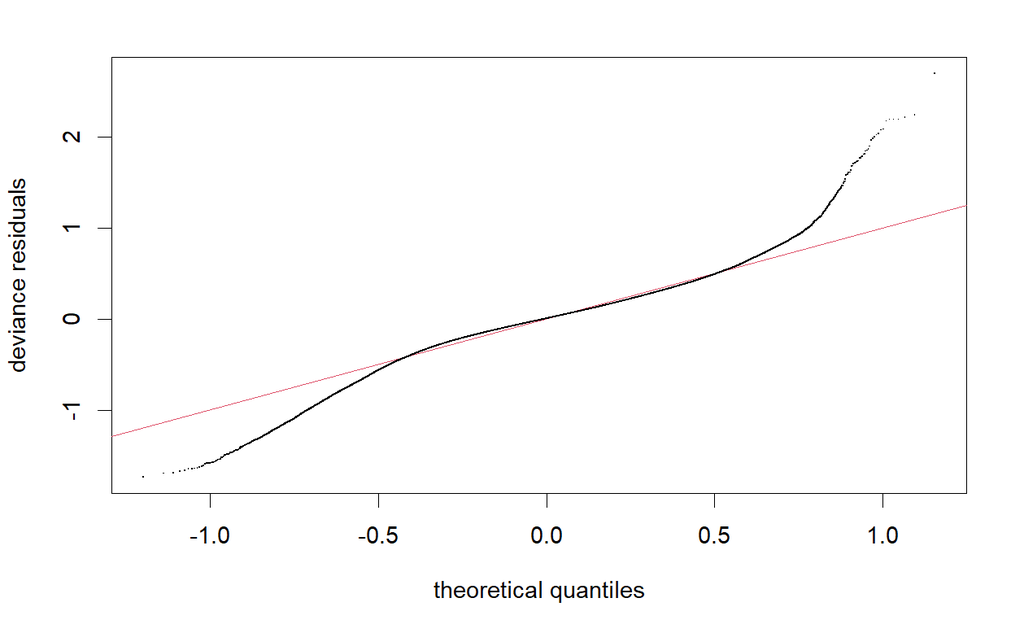

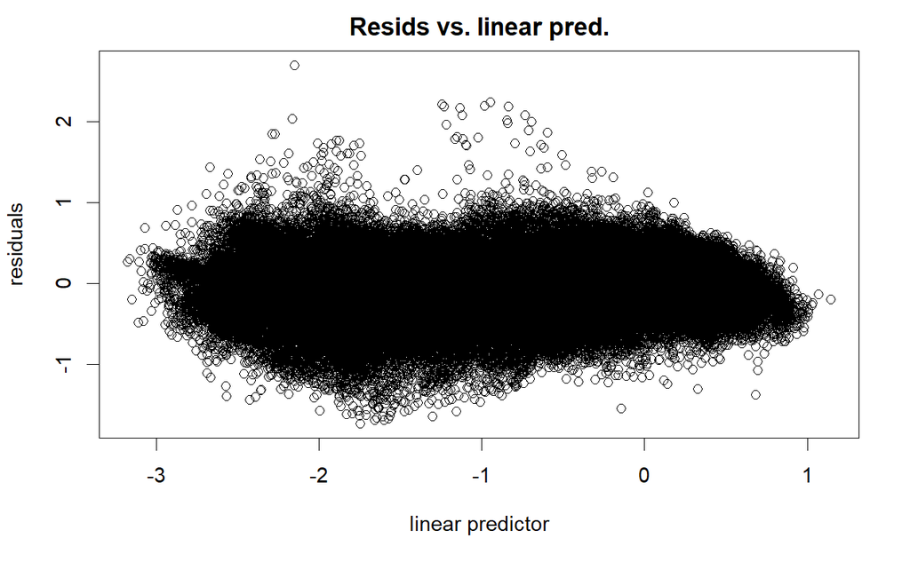

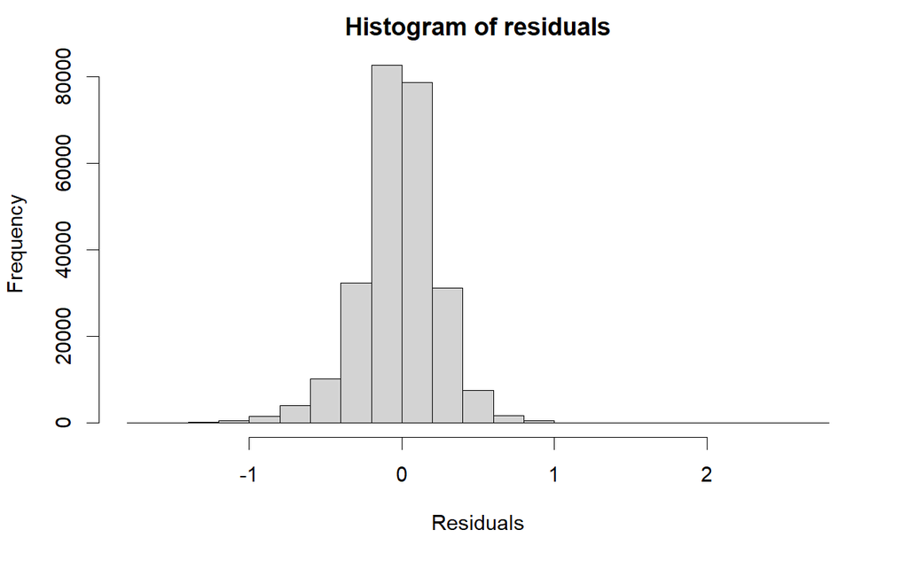

```
Method: REML   Optimizer: outer newton
full convergence after 14 iterations.
Gradient range [-0.009535211,0.008034349]
(score 13036.98 & scale 0.06475765).
Hessian positive definite, eigenvalue range [2.438915,125666].
Model rank =  93 / 93

Basis dimension (k) checking results. Low p-value (k-index<1) may
indicate that k is too low, especially if edf is close to k'.

                k'   edf k-index p-value
s(map)       15.00 14.91    1.00    0.69
s(cv)         7.00  6.98    0.97    0.15
s(ugi)        7.00  6.99    0.98    0.15
s(season)    11.00 10.95    0.95  <2e-16 ***
s(onset_sd)   7.00  6.88    0.99    0.50
s(wet95)      5.00  4.96    1.00    0.67
s(intensity)  7.00  6.96    1.00    0.59
s(soilN)      7.00  6.99    1.02    0.96
s(sand)       5.00  4.98    0.98    0.23
s(lst_mean)   7.00  6.99    0.96    0.02 *
s(meanT)      7.00  6.99    0.98    0.26
s(fire)       7.00  6.95    0.98    0.18
---
Signif. codes:  0 ‘***’ 0.001 ‘**’ 0.01 ‘*’ 0.05 ‘.’ 0.1 ‘ ’ 1
```

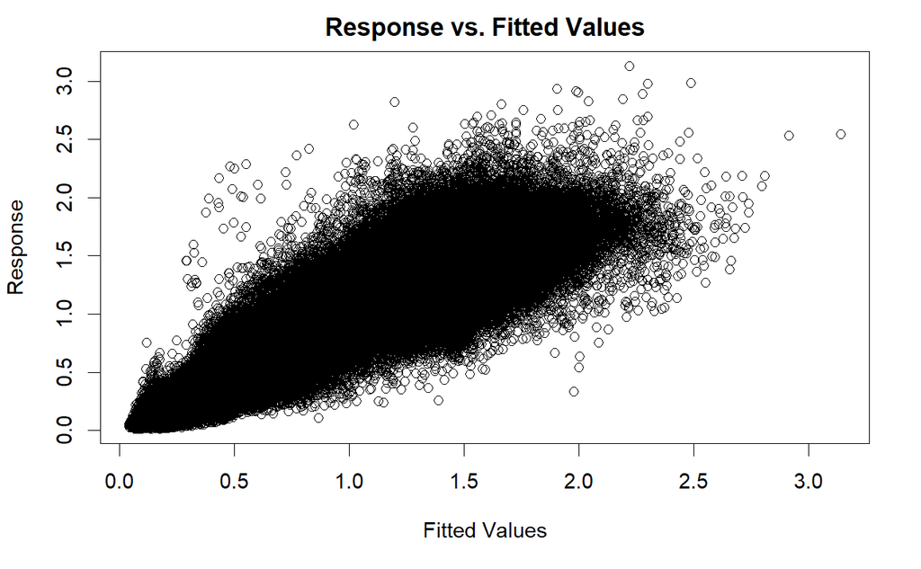

```r
gam.check(mod1)
```

Now I add the spatial term to account for the spatial structure in the model residuals.

````r
```r

# Spatial model - high smoothing (k = c(8,8) for spatial term)
Sys.time()
t1 <- Sys.time()
mod2_k8 <- bam(gpp ~ s(map, k = 16, bs = \ts\) + s(cv, k = 8, bs = \ts\) +
              s(ugi, k = 8, bs = \ts\) +
              s(season, k = 12, bs = \ts\) + s(onset_sd, k = 8, bs = \ts\) +
              s(wet95, k = 6, bs = \ts\) + s(intensity, k = 8, bs = \ts\) +
              s(soilN, k = 8, bs = \ts\) + s(sand, k = 6, bs = \ts\) +
              s(lst_mean, k = 8, bs = \ts\) +
              s(meanT, k = 8, bs = \ts\) +
              s(fire, k = 8, bs = \ts\) +
              te(x, y, k = c(8, 8), bs = \ts\),
            data = df_model,
            method = \REML\,
            family = Gamma(link = \log\),
            select = TRUE,
            cluster = nc)
t2 <- Sys.time()
t2 - t1

beep(5)

# Spatial model - medium smoothing (k = c(12,12) for spatial term)
Sys.time()
t1 <- Sys.time()
mod2_k12 <- bam(gpp ~ s(map, k = 16, bs = \ts\) + s(cv, k = 8, bs = \ts\) +
              s(ugi, k = 8, bs = \ts\) +
              s(season, k = 12, bs = \ts\) + s(onset_sd, k = 8, bs = \ts\) +
              s(wet95, k = 6, bs = \ts\) + s(intensity, k = 8, bs = \ts\) +
              s(soilN, k = 8, bs = \ts\) + s(sand, k = 6, bs = \ts\) +
              s(lst_mean, k = 8, bs = \ts\) +
              s(meanT, k = 8, bs = \ts\) +
              s(fire, k = 8, bs = \ts\) +
              te(x, y, k = c(12, 12), bs = \ts\),
            data = df_model,
            method = \REML\,
            family = Gamma(link = \log\),
            select = TRUE,
            cluster = nc)
t2 <- Sys.time()
t2 - t1

beep(5)

# Spatial model - low smoothing (k = c(16,16) for spatial term)

Sys.time()
t1 <- Sys.time()
mod2_k16 <- bam(gpp ~ s(map, k = 16, bs = \ts\) + s(cv, k = 8, bs = \ts\) +
              s(ugi, k = 8, bs = \ts\) +
              s(season, k = 12, bs = \ts\) + s(onset_sd, k = 8, bs = \ts\) +
              s(wet95, k = 6, bs = \ts\) + s(intensity, k = 8, bs = \ts\) +
              s(soilN, k = 8, bs = \ts\) + s(sand, k = 6, bs = \ts\) +
              s(lst_mean, k = 8, bs = \ts\) +
              s(meanT, k = 8, bs = \ts\) +
              s(fire, k = 8, bs = \ts\) +
              te(x, y, k = c(16, 16), bs = \ts\),
            data = df_model,
            method = \REML\,
            family = Gamma(link = \log\),
            select = TRUE,
            cluster = nc)
t2 <- Sys.time()
t2 - t1

beep(3)

# # Save/load model results

# saveRDS(mod2_k8, \processed_data/models/mod2_k8.rds\)
# saveRDS(mod2_k12, \processed_data/models/mod2_k12.rds\)
# saveRDS(mod2_k16, \processed_data/models/mod2_k16.rds\)
# mod2_k8 <- readRDS(\processed_data/models/mod2_k8.rds\)
# mod2_k12 <- readRDS(\processed_data/models/mod2_k12.rds\)
# mod2_k16 <- readRDS(\processed_data/models/mod2_k16.rds\)

# Model 2 results

plot(mod2_k8, shade = TRUE, seWithMean = TRUE, scheme = 2,
     pages = 3)
plot(mod2_k12, shade = TRUE, seWithMean = TRUE, scheme = 2,
     pages = 3)
plot(mod2_k16, shade = TRUE, seWithMean = TRUE, scheme = 2,
     pages = 3)

print(\Spatial term k = 8\)
gam.check(mod2_k8)
print(\Spatial term k = 12\)
gam.check(mod2_k12)
print(\Spatial term k = 16\)
gam.check(mod2_k16)


beep(3)
````

[output not shown]

[output not shown]

[output cut: 66 more lines]

[output not shown]

Model diagnostic and residual plots

````r
```r

# Model diagnostic plots

mod1_diag <- appraise(mod1, n_bins = 60, point_alpha = 0.05, line_col = \#888888\)
ggsave(paste0(plot_dir, \mod1_diag_plot.jpg\),
       plot = mod1_diag,
       width = 20, height = 16, units = \cm\, dpi = 300)

mod2_k8_diag <- appraise(mod2_k8, n_bins = 60, point_alpha = 0.05, line_col = \#117733\)
ggsave(paste0(plot_dir, \mod2_k8_diag_plot.jpg\),
       plot = mod2_k8_diag,
       width = 20, height = 16, units = \cm\, dpi = 300)

mod2_k12_diag <- appraise(mod2_k8, n_bins = 60, point_alpha = 0.05, line_col = \#117733\)
ggsave(paste0(plot_dir, \mod2_k12_diag_plot.jpg\),
       plot = mod2_k12_diag,
       width = 20, height = 16, units = \cm\, dpi = 300)

mod2_k16_diag <- appraise(mod2_k8, n_bins = 60, point_alpha = 0.05, line_col = \#117733\)
ggsave(paste0(plot_dir, \mod2_k16_diag_plot.jpg\),
       plot = mod2_k16_diag,
       width = 20, height = 16, units = \cm\, dpi = 300)

# Residual map
resid_raster <- df_model %>%
  mutate(resids = residuals(mod2_k16)) %>%
  select(x, y, resids) %>%
  rast(crs = \EPSG:4326\)

resid_plot <- tm_shape(resid_raster) +
  tm_raster(palette = \RdYlBu\, style = \cont\,
            breaks = c(-0.5, -0.25, 0, 0.25, 0.5),
            title = \Model residuals\) +
  sa_basemap_2 +
  africa_basemap

tmap_save(resid_plot,
          paste0(plot_dir, \mod2_resid_map.jpg\),
          width = 16, height = 12, unit = \cm\, dpi = 300)
````

[output not shown]